# R Notebook

**Principles of Data Visualization and Introduction to ggplot2**

I have provided you with data about the 5,000 fastest growing companies in the US, as compiled by Inc. magazine. lets read this in:

```r
inc <- read.csv("https://raw.githubusercontent.com/charleyferrari/CUNY_DATA_608/master/module1/Data/inc5000_data.csv", header= TRUE)
```

And lets preview this data:

```r
head(inc)
```

```
##   Rank                         Name Growth_Rate   Revenue
## 1    1                         Fuhu      421.48 1.179e+08
## 2    2        FederalConference.com      248.31 4.960e+07
## 3    3                The HCI Group      245.45 2.550e+07
## 4    4                      Bridger      233.08 1.900e+09
## 5    5                       DataXu      213.37 8.700e+07
## 6    6 MileStone Community Builders      179.38 4.570e+07
##                       Industry Employees         City State
## 1 Consumer Products & Services       104   El Segundo    CA
## 2          Government Services        51     Dumfries    VA
## 3                       Health       132 Jacksonville    FL
## 4                       Energy        50      Addison    TX
## 5      Advertising & Marketing       220       Boston    MA
## 6                  Real Estate        63       Austin    TX
```

```r
summary(inc)
```

```
##       Rank                          Name       Growth_Rate
##  Min.   :   1   (Add)ventures         :   1   Min.   :  0.340
##  1st Qu.:1252   @Properties           :   1   1st Qu.:  0.770
##  Median :2502   1-Stop Translation USA:   1   Median :  1.420
##  Mean   :2502   110 Consulting        :   1   Mean   :  4.612
##  3rd Qu.:3751   11thStreetCoffee.com  :   1   3rd Qu.:  3.290
##  Max.   :5000   123 Exteriors         :   1   Max.   :421.480
##                 (Other)               :4995
##     Revenue                                  Industry      Employees
##  Min.   :2.000e+06   IT Services                 : 733   Min.   :    1.0
##  1st Qu.:5.100e+06   Business Products & Services: 482   1st Qu.:   25.0
##  Median :1.090e+07   Advertising & Marketing     : 471   Median :   53.0
##  Mean   :4.822e+07   Health                      : 355   Mean   :  232.7
##  3rd Qu.:2.860e+07   Software                    : 342   3rd Qu.:  132.0
##  Max.   :1.010e+10   Financial Services          : 260   Max.   :66803.0
##                      (Other)                     :2358   NA's   :12
##             City          State
##  New York     : 160   CA     : 701
##  Chicago      :  90   TX     : 387
##  Austin       :  88   NY     : 311
##  Houston      :  76   VA     : 283
##  San Francisco:  75   FL     : 282
##  Atlanta      :  74   IL     : 273
##  (Other)      :4438   (Other):2764
```

Think a bit on what these summaries mean. Use the space below to add some more relevant non-visual exploratory information you think helps you understand this data:

```r
describe(inc)
```

```
## inc
##
##  8  Variables      5001  Observations
## ---------------------------------------------------------------------------
## Rank
##        n  missing distinct     Info     Mean      Gmd      .05      .10
##     5001        0     4999        1     2502     1667      252      502
##      .25      .50      .75      .90      .95
##     1252     2502     3751     4501     4751
##
## lowest :    1    2    3    4    5, highest: 4996 4997 4998 4999 5000
## ---------------------------------------------------------------------------
## Name
##        n  missing distinct
##     5001        0     5001
##
## lowest : (Add)ventures                          @Properties                            1-Stop Translation USA                 110 Consulting                         11thStreetCoffee.com
## highest: Zoup!                                  ZT Wealth and Altus Group of Companies Zumasys                                Zurple                                 ZweigWhite
## ---------------------------------------------------------------------------
## Growth_Rate
##        n  missing distinct     Info     Mean      Gmd      .05      .10
##     5001        0     1147        1    4.612    6.493     0.43     0.50
##      .25      .50      .75      .90      .95
##     0.77     1.42     3.29     9.12    17.16
##
## lowest :   0.34   0.35   0.36   0.37   0.38, highest: 213.37 233.08 245.45 248.31 421.48
## ---------------------------------------------------------------------------
## Revenue
##         n   missing  distinct      Info      Mean       Gmd       .05
##      5001         0      1069         1  48222535  75111227   2400000
##       .10       .25       .50       .75       .90       .95
##   3000000   5100000  10900000  28600000  76900000 155600000
##
## lowest : 2.00e+06 2.10e+06 2.20e+06 2.30e+06 2.40e+06
## highest: 3.80e+09 4.50e+09 4.60e+09 4.70e+09 1.01e+10
## ---------------------------------------------------------------------------
## Industry
##        n  missing distinct
##     5001        0       25
##
```

[output cut: 9 more lines]

```
## lowest :     1     2     3     4     5, highest: 17057 18887 20000 32000 66803
## ---------------------------------------------------------------------------
## City
##        n  missing distinct
##     5001        0     1519
##
## lowest : Acton        Addison      Adrian       Agoura Hills Aiea
## highest: Worthington  Wyomissing   Yonkers      Youngsville  Zumbrota
## ---------------------------------------------------------------------------
## State
##        n  missing distinct
##     5001        0       52
##
## lowest : AK AL AR AZ CA, highest: VT WA WI WV WY
## ---------------------------------------------------------------------------
```

```r
str(inc)
```

```
## 'data.frame':    5001 obs. of  8 variables:
##  $ Rank       : int  1 2 3 4 5 6 7 8 9 10 ...
##  $ Name       : Factor w/ 5001 levels "(Add)ventures",..: 1770 1633 4423 690 1198 2839 4733 1468 1869 4968 ...
##  $ Growth_Rate: num  421 248 245 233 213 ...
##  $ Revenue    : num  1.18e+08 4.96e+07 2.55e+07 1.90e+09 8.70e+07 ...
##  $ Industry   : Factor w/ 25 levels "Advertising & Marketing",..: 5 12 13 7 1 20 10 1 5 21 ...
##  $ Employees  : int  104 51 132 50 220 63 27 75 97 15 ...
##  $ City       : Factor w/ 1519 levels "Acton","Addison",..: 391 365 635 2 139 66 912 1179 131 1418 ...
##  $ State      : Factor w/ 52 levels "AK","AL","AR",..: 5 47 10 45 20 45 44 5 46 41 ...
```

- Summary of Employees by Industry

```r
inc %>%
  filter(complete.cases(.)) %>%
  group_by(Industry) %>%
  summarise(count = n(),
            min = min(Employees),
            avg = mean(Employees),
            med = median(Employees),
            max = max(Employees)) %>%
  arrange(desc(med))
```

```
## # A tibble: 25 x 6
##    Industry               count   min   avg   med   max
##    <fct>                  <int> <dbl> <dbl> <dbl> <dbl>
##  1 Security                  73     7  562.  77   20000
##  2 Human Resources          196     4 1158.  71.5 66803
##  3 Government Services      202     6  130.  71    1352
##  4 Health                   354     2  233.  71    4390
##  5 Energy                   109     2  243.  70    2501
##  6 Financial Services       260     5  183.  70    1829
##  7 Software                 341     1  150.  69    3000
##  8 Environmental Services    51     4  199.  67    5347
##  9 Food & Beverage          129     3  511.  65    7681
## 10 Telecommunications       127     6  243.  65   10000
## # ... with 15 more rows
```

- Number of Unique Cities Appears by State

```r
inc %>%
  group_by(State) %>%
  summarise(Cities = n_distinct(City)) %>%
  arrange(desc(Cities))
```

```
## # A tibble: 52 x 2
##    State Cities
##    <fct>  <int>
##  1 CA       204
##  2 IL       104
##  3 FL       102
##  4 NJ        97
##  5 NY        90
##  6 PA        80
##  7 OH        79
##  8 MA        72
##  9 TX        67
## 10 VA        56
## # ... with 42 more rows
```

- Summary of Growth Rate by Industry

```r
inc %>%
  filter(complete.cases(.)) %>%
  group_by(Industry) %>%
  summarise(count = n(),
            min = min(Growth_Rate),
            avg = mean(Growth_Rate),
            med = median(Growth_Rate),
            max = max(Growth_Rate)) %>%
  arrange(desc(med))
```

```
## # A tibble: 25 x 6
##    Industry                     count   min   avg   med   max
##    <fct>                        <int> <dbl> <dbl> <dbl> <dbl>
##  1 Government Services            202  0.35  7.24  2.11 248.
##  2 Energy                         109  0.35  9.60  2.08 233.
##  3 Real Estate                     95  0.35  7.82  2.08 179.
##  4 Media                           54  0.41  4.37  1.94  23.0
##  5 Consumer Products & Services   203  0.35  8.78  1.82 421.
##  6 Retail                         203  0.34  6.18  1.76 167.
##  7 Software                       341  0.35  5.03  1.7  129.
##  8 Advertising & Marketing        471  0.35  6.23  1.61 213.
##  9 Health                         354  0.35  4.87  1.57 245.
## 10 Security                        73  0.37  3.39  1.54  31.2
## # ... with 15 more rows
```

- Correlation between Number of Employees and Growth Rate

```r
temp <- inc %>%
  filter(complete.cases(.))
cor(temp$Employees, temp$Growth_Rate)
```

```
## [1] -0.0178689
```

## Question 1

Create a graph that shows the distribution of companies in the dataset by State (ie how many are in each state). There are a lot of States, so consider which axis you should use. This visualization is ultimately going to be consumed on a ‘portrait’ oriented screen (ie taller than wide), which should further guide your layout choices.

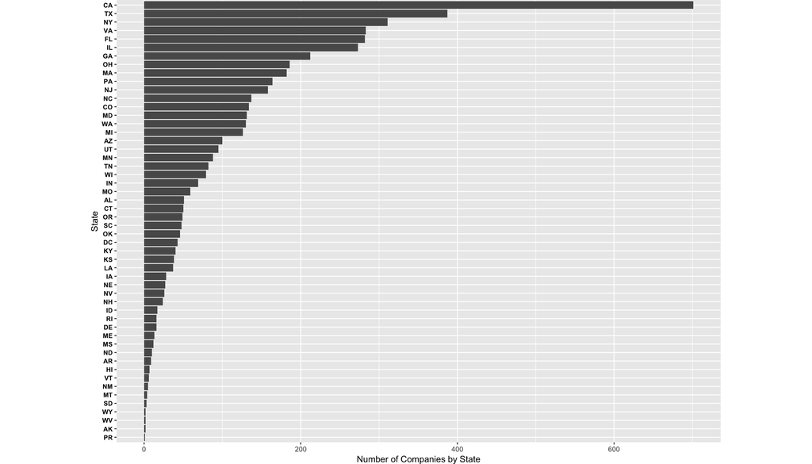

## Question 2

Lets dig in on the state with the 3rd most companies in the data set. Imagine you work for the state and are interested in how many people are employed by companies in different industries. Create a plot that shows the average and/or median employment by industry for companies in this state (only use cases with full data, use R’s `complete.cases()` function.) In addition to this, your graph should show how variable the ranges are, and you should deal with outliers.

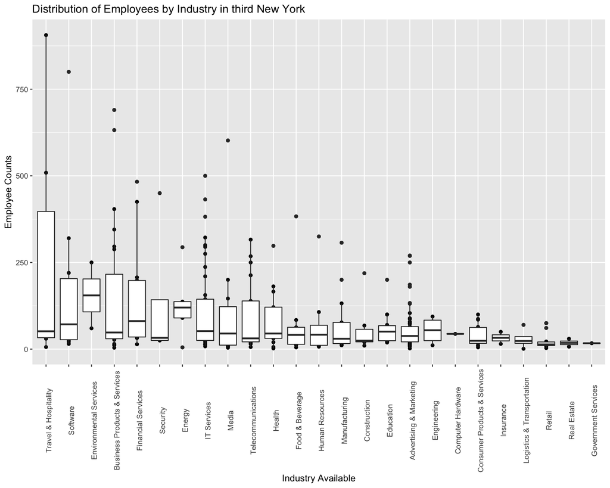

## Question 3

Now imagine you work for an investor and want to see which industries generate the most revenue per employee. Create a chart that makes this information clear. Once again, the distribution per industry should be shown.

[figure not shown]